# Does a common first name poison the standout test?

The standout measures how far the true first name is lifted beyond a *typical same-language name*. That built-in comparison has a cost: if the true name *is* a typical name, it cannot stand out, however well the model knows the person. This plots, for each person, how common their first name is (x, its base-rate percentile among same-language names) against the standout (y). Green points are people who came of age before the cutoff — the model knows them, so at equal knowledge their height should be flat. It is not.

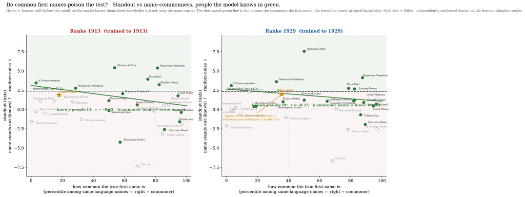

Among the known (green) people the fit slopes down — 1929 model r = -0.23 — so yes, commonness drags the score: Einstein→“Albert” (-1.9), Tolstoy→“Leo”, Curie→ “Marie” and Wagner→“Richard” all sit low with ordinary names, while Anatole France and Nietzsche ride high with unusual ones. But the effect is *modest* (r ≈ −0.2), and the x-axis is imperfect: “Napoleon” and “Otto” are frequent tokens yet still distinctive (no one else is Napoleon), so they ride high despite a high percentile. Base-rate commonness is not the same as confusability.

**The sharper point is the gold star.** The free-continuation probe already showed the 1929 model knows Hitler, yet Hitler→“Adolf” lands at +2.0 — right at the line — and “Adolf” is not even a common name (36th percentile). So the standout under-credits a person we *know* is known. Read the whole picture together: the test has essentially no false positives (no post-cutoff person clears the line) but many false negatives (it misses known people whose first name is common or merely ordinary). It is a *conservative, specific* instrument — clearing the line proves knowledge, but sitting below it does not prove ignorance. Good for “no contamination”, poor as a sensitive time-lock.

| person | b+25 | name commonness | standout 1929 |
| --- | --- | --- | --- |
| Bonaparte → Napoleon | 1794 | 88% | +4.1 |
| Wagner → Richard | 1838 | 96% | +0.7 |
| Bismarck → Otto | 1840 | 50% | +7.6 |
| Marx → Karl | 1843 | 79% | +2.7 |
| Douglass → Frederick | 1843 | 65% | +1.1 |
| Tolstoy → Leo | 1853 | 86% | -0.7 |
| Stanley → Henry | 1866 | 82% | +2.7 |
| Nietzsche → Friedrich | 1869 | 32% | +3.6 |
| France → Anatole | 1869 | 3% | +3.1 |
| Curie → Marie | 1892 | 94% | +0.5 |
| Lenin → Vladimir | 1895 | 82% | +1.1 |
| Einstein → Albert | 1904 | 89% | -1.9 |
| Picasso → Pablo | 1906 | 36% | +1.0 |
| Stravinsky → Igor | 1907 | 50% | +1.2 |
| Mussolini → Benito | 1908 | 19% | +0.4 |
| Hitler → Adolf | 1914 | 36% | +2.0 |
| de Gaulle → Charles | 1915 | 97% | -2.5 |
| Hemingway → Ernest | 1924 | 18% | +0.4 |
| Lindbergh → Charles | 1927 | 82% | +1.2 |
| Orwell → George | 1928 | 88% | +0.9 |
| Reagan → Ronald | 1936 | 9% | -0.6 |
| Pollock → Jackson | 1937 | 38% | -1.0 |
| Parks → Rosa | 1938 | 5% | -0.1 |
| Camus → Albert | 1938 | 78% | -2.6 |
| Salk → Jonas | 1939 | 15% | +2.3 |
| Monk → Thelonious | 1942 | 0% | -2.1 |
| Feynman → Richard | 1943 | 71% | +0.2 |
| Berry → Chuck | 1951 | 3% | +0.0 |
| Guevara → Che | 1953 | 68% | -6.7 |
| Armstrong → Neil | 1955 | 6% | +0.3 |